# Reproducible Research: Peer Assessment 1

## Loading and preprocessing the data

```r
library(lubridate)
```

```r
library(ggplot2)
library(gridExtra)
library(grid)
zipF<- "activity.zip"
unzip(zipF)
data <- read.csv("activity.csv", stringsAsFactors = FALSE)
data$date <- as.Date(data$date, format = "%Y-%m-%d")
```

### Calculate the total number of steps taken per day

```r
dfs <- aggregate(steps ~ date, rm.na = TRUE, data = data, FUN = sum)
```

### Make a histogram of the total number of steps taken each day

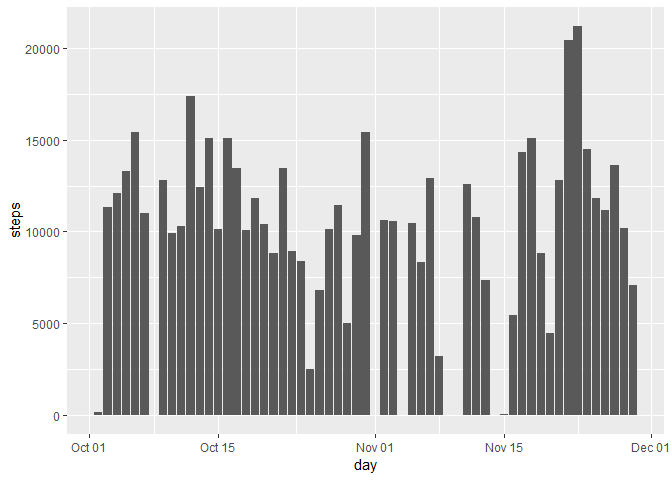

```r
ggplot(data=dfs, aes(x=date,y=steps))+xlab("day")+geom_histogram(stat="identity")
```

## What is mean total number of steps taken per day?

```r
aggregate(steps ~ date, data = data, FUN = mean)
```

```
##          date      steps
## 1  2012-10-02  0.4375000
## 2  2012-10-03 39.4166667
## 3  2012-10-04 42.0694444
## 4  2012-10-05 46.1597222
## 5  2012-10-06 53.5416667
## 6  2012-10-07 38.2465278
## 7  2012-10-09 44.4826389
## 8  2012-10-10 34.3750000
## 9  2012-10-11 35.7777778
## 10 2012-10-12 60.3541667
## 11 2012-10-13 43.1458333
## 12 2012-10-14 52.4236111
## 13 2012-10-15 35.2048611
## 14 2012-10-16 52.3750000
```

[output cut: 39 more lines]

```r
aggregate(steps ~ date, data = data, FUN = median)
```

```
##          date steps
## 1  2012-10-02     0
## 2  2012-10-03     0
## 3  2012-10-04     0
## 4  2012-10-05     0
## 5  2012-10-06     0
## 6  2012-10-07     0
## 7  2012-10-09     0
## 8  2012-10-10     0
## 9  2012-10-11     0
## 10 2012-10-12     0
## 11 2012-10-13     0
## 12 2012-10-14     0
## 13 2012-10-15     0
## 14 2012-10-16     0
```

[output cut: 39 more lines]

## What is the average daily activity pattern?

### Make a time series plot of the 5-minute interval (x-axis) and the average number of steps taken, averaged across all days (y-axis)

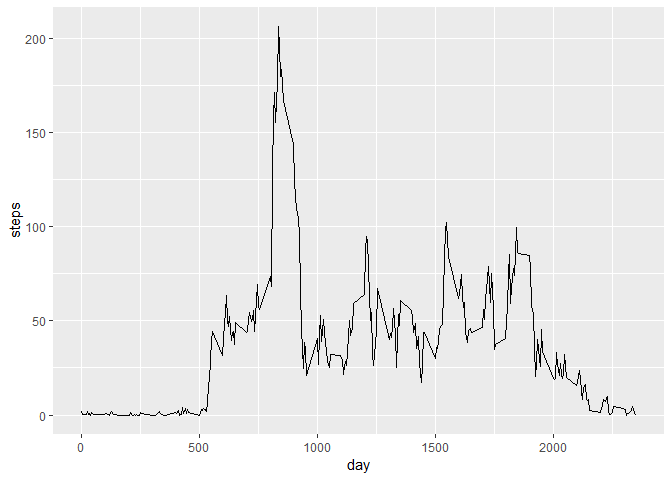

```r
mn <- aggregate(steps ~ interval, data = data, FUN = mean)
ggplot(data=mn, aes(x=interval,y=steps))+xlab("day")+geom_line(stat="identity")
```

```r
max(data$steps, na.rm = TRUE)
```

```
## [1] 806
```

## Imputing missing values

```r
sum(is.na(data))
```

```
## [1] 2304
```

### Devise a strategy for filling in all of the missing values in the dataset. The strategy does not need to be sophisticated.

Since there are intervals and days with NA I am going to fill in the missing values with the average number of steps of the whole 2 months

### Create a new dataset that is equal to the original dataset but with the missing data filled in.

```r
ave <- mean(na.omit(data$steps))
new_data <- data
new_data$steps[is.na(new_data$steps)] <- ave
new_data$date <- as.Date(new_data$date, format = "%Y-%m-%d")
```

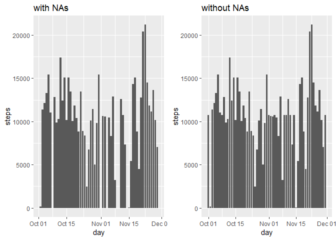

```r
p1 <- ggplot(data=dfs, aes(x=date,y=steps))+xlab("day")+geom_histogram(stat="identity")+ggtitle("with NAs")
new_dfs <- aggregate(steps ~ date, rm.na = TRUE, data = new_data, FUN = sum)
p2 <- ggplot(data=new_dfs, aes(x=date,y=steps))+xlab("day")+geom_histogram(stat="identity")+ggtitle("without NAs")
grid.arrange(p1, p2, nrow = 1)
```

```r
aggregate(steps ~ date, data = new_data, FUN = mean)
```

```
##          date      steps
## 1  2012-10-01 37.3825996
## 2  2012-10-02  0.4375000
## 3  2012-10-03 39.4166667
## 4  2012-10-04 42.0694444
## 5  2012-10-05 46.1597222
## 6  2012-10-06 53.5416667
## 7  2012-10-07 38.2465278
## 8  2012-10-08 37.3825996
## 9  2012-10-09 44.4826389
## 10 2012-10-10 34.3750000
## 11 2012-10-11 35.7777778
## 12 2012-10-12 60.3541667
## 13 2012-10-13 43.1458333
## 14 2012-10-14 52.4236111
```

[output cut: 47 more lines]

```r
aggregate(steps ~ date, data = new_data, FUN = median)
```

```
##          date   steps
## 1  2012-10-01 37.3826
## 2  2012-10-02  0.0000
## 3  2012-10-03  0.0000
## 4  2012-10-04  0.0000
## 5  2012-10-05  0.0000
## 6  2012-10-06  0.0000
## 7  2012-10-07  0.0000
## 8  2012-10-08 37.3826
## 9  2012-10-09  0.0000
## 10 2012-10-10  0.0000
## 11 2012-10-11  0.0000
## 12 2012-10-12  0.0000
## 13 2012-10-13  0.0000
## 14 2012-10-14  0.0000
```

[output cut: 47 more lines]

## Are there differences in activity patterns between weekdays and weekends?

### Create a new factor variable in the dataset with two levels – “weekday” and “weekend” indicating whether a given date is a weekday or weekend day.

```r
new_data$weekday <- factor(format(new_data$date, "%A"))
levels(new_data$weekday) <- list(weekday=c("Monday","Tuesday","Wednesday","Thursday","Friday"), weekend = c("Saturday", "Sunday"))
new_data_mean <- aggregate(steps~interval + weekday, new_data, mean, na.rm = TRUE)
```

### Make a panel plot containing a time series plot (i.e. type=“l”) of the 5-minute interval (x-axis) and the average number of steps taken, averaged across all weekday days or weekend days (y-axis). See the README file in the GitHub repository to see an example of what this plot should look like using simulated data

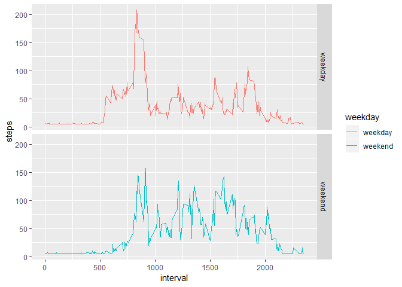

```r
ggplot(new_data_mean, aes(x = interval , y = steps, color=weekday)) +geom_line()+facet_grid(weekday~.)
```